# Regression Analysis Assignment 1

The CSV data file (above) contains 24 months of electricity consumption data for an office building in New York City, as well as average monthly outdoor air temperature (OAT) for each of the corresponding months. To successfully complete this assignment, you will:

### Data Cleaning and Basic Plot

- *Read the CSV file into the RStudio environment, then create a data frame containing just the electricity and OAT data.*

We generate the utility df by averaging the monthly OAT data and slicing the results to line up with the consumption dataframe.

```r
setwd("~/Documents/honeys_class/energy_data/regression_analysis")
source('parse_energy_files.R')
require(ggplot2)
require(segmented)
require(scales)
data = parse_energy_files(getwd())  # parses csvs and constructs average monthly oat from daily oat
oat = data$oat
consumption = data$data
start = as.Date('2014-07-31','%Y-%m-%d')
end = as.Date('2016-06-30', '%Y-%m-%d')
oat = slice_oat_by_end_date(start, end, oat)
elec = consumption$Elec
elec_utility = data.frame(oat, elec)
elec_utility
```

| oat | elec |
| --- | --- |
| 76.24194 | 3531.763 |
| 74.43871 | 3413.148 |
| 70.15333 | 3283.193 |
| 60.25484 | 2895.976 |
| 45.16000 | 2701.517 |
| 40.39677 | 2744.952 |
| 30.01613 | 2742.910 |
| 24.40000 | 2827.230 |
| 37.51613 | 2767.857 |
| 52.57667 | 2729.934 |

[output cut: 14 more lines]

A quick look at how electricity consumption increases with average monthly temperature

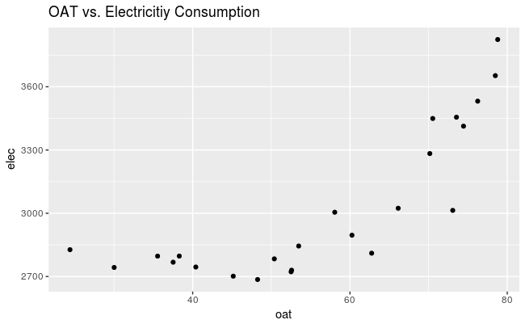

```r
ggplot(data=elec_utility, aes(x=oat, y=elec)) +
    geom_point() +
    ggtitle('OAT vs. Electricitiy Consumption')
```

- *Use the installed stats package, or any other package of your choosing, to generate a generalized linear model of the electricity consumption vs. the OAT data. Plot the data with the best fit regression line and generate summary statistics for the model that include the adjusted R-squared value.*

### Simple Linear Regression

A basic linear regression. Electricity consumption is set as the response variable to monthly average outside air temperature.

```r
# generating a basic linear regression from elec ~ oat
regr = lm(elec ~ oat,data = elec_utility)
summary(regr)
```

```
Call:
lm(formula = elec ~ oat, data = elec_utility)

Residuals:
    Min      1Q  Median      3Q     Max
-321.55 -173.12   10.57  145.51  416.32

Coefficients:
            Estimate Std. Error t value Pr(>|t|)
(Intercept) 2053.186    155.807  13.178 6.45e-12 ***
oat           17.192      2.662   6.459 1.69e-06 ***
---
Signif. codes:  0 ‘***’ 0.001 ‘**’ 0.01 ‘*’ 0.05 ‘.’ 0.1 ‘ ’ 1

Residual standard error: 209.3 on 22 degrees of freedom
Multiple R-squared:  0.6547,    Adjusted R-squared:  0.639
F-statistic: 41.72 on 1 and 22 DF,  p-value: 1.692e-06
```

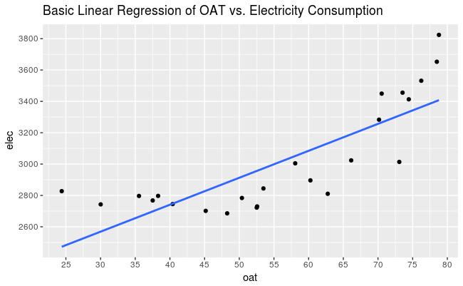

```r
ggplot(data=elec_utility, aes(x=oat, y=elec)) +
    geom_point() +
    geom_smooth(method='lm',formula=y~x, se=F) +
    scale_x_continuous(breaks=pretty_breaks(10)) +
    scale_y_continuous(breaks=pretty_breaks(8)) +
    ggtitle('Basic Linear Regression of OAT vs. Electricity Consumption')
```

- *Use the segmented R package to generate a segmented (piecewise) linear regression model of the electricity consumption vs. the OAT data. Plot the data with the best fit lines and generate summary statistics for the model that include the adjusted R-squared value and the change-point (breakpoint).*

### Piecewise Regression using segmented()

We wrap the results of the linear regression in a segmented.lm() method to derive a change point for the model

```r
seg_regr = segmented.lm(regr, seg.Z= ~oat,control=seg.control(display=F, K=4, stop.if.error=FALSE))
summary(seg_regr)
```

```
    ***Regression Model with Segmented Relationship(s)***

Call:
segmented.lm(obj = regr, seg.Z = ~oat, control = seg.control(display = F,
    K = 4, stop.if.error = FALSE))

Estimated Break-Point(s):
   Est. St.Err
62.766  2.569

Meaningful coefficients of the linear terms:
            Estimate Std. Error t value Pr(>|t|)
(Intercept) 2679.478    134.128  19.977  1.1e-14 ***
oat            2.435      2.838   0.858    0.401
U1.oat        50.847     10.696   4.754       NA
---
Signif. codes:  0 ‘***’ 0.001 ‘**’ 0.01 ‘*’ 0.05 ‘.’ 0.1 ‘ ’ 1

Residual standard error: 120.1 on 20 degrees of freedom
Multiple R-Squared: 0.8967,  Adjusted R-squared: 0.8812

Convergence attained in 2 iterations with relative change -8.07183e-16
```

Looking at the slopes of both

```r
slope(seg_regr)
```

```
$oat
         Est. St.Err. t value CI(95%).l CI(95%).u
slope1  2.435   2.838  0.8579    -3.486     8.356
slope2 53.280  10.310  5.1670    31.770    74.790
```

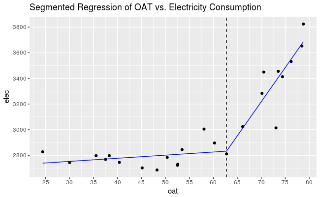

```r
ggplot(data=elec_utility, aes(x=oat, y=elec)) +
    geom_point() +
    geom_line(aes(x=oat, y=broken.line(seg_regr)$fit), color='blue') +
    geom_vline(xintercept=summary.segmented(seg_regr)$psi[1,2], linetype='dashed') +
    scale_x_continuous(breaks=pretty_breaks(10)) +
    scale_y_continuous(breaks=pretty_breaks(8)) +
    ggtitle('Segmented Regression of OAT vs. Electricity Consumption')
```

*Answer the following questions:*

*How are the two models different, with regard to:* -Appearance -Adjusted R-squared values

The initial model is a 2P (non-breakpoint) regression line with an adjusted-R2 of .63. The 4P breakpoint model changes slope at an OAT of 62 with an adjusted R2 of .89. The 4P is significantly more accurate with its high adjusted R2 value.

*What does the segmented model tell you about the building, through the:* - Change-point (breakpoint) - Slope(s) of the best fit lines

The slope above the change point shows that as OAT increases past 62.7, the rate of energy consumption dramatically increases. It could be inferred from the model that this is energy spent on cooling the building during hot months. The slope to the left of the change point is relatively flat, with only a slight increase in energy output as OAT increases. It can be inferred that the baseload of the building sits around 2800 kwH.